# Introduction

This is a data analysis practical exercise designed to gain insights into Netflix library offering and strategy and how it has evolved over the years. The data for this analysis was taken from the Netflix Movies and TV Shows sample data set posted by Shivam Bansal on Kaggle. A link to the data set download page can be found [here](https://www.kaggle.com/datasets/shivamb/netflix-shows/code).

In this analysis notebook, I work through loading and exploring the data, cleaning issues found within the data, conduct a category analysis, and supplement the analysis by comparing the data to Netflix stock performance during the same time period.

# Loading, Exploring, and Cleaning Data:

### Loading

```python
#import data and pandas
import pandas as pd
import matplotlib.pyplot as plt

df = pd.read_csv("netflix_titles.csv")
```

```python
df.shape          # rows, columns
```

```
(8807, 12)
```

```python
df.dtypes         # column types
```

```
show_id           str
type              str
title             str
director          str
cast              str
country           str
date_added        str
release_year    int64
rating            str
duration          str
listed_in         str
description       str
dtype: object
```

```python
df.head()         # first few rows
```

|  | show_id | type | title | director | cast | country | date_added | release_year | rating | duration | listed_in | description |
| --- | --- | --- | --- | --- | --- | --- | --- | --- | --- | --- | --- | --- |
| 0 | s1 | Movie | Dick Johnson Is Dead | Kirsten Johnson | NaN | United States | September 25, 2021 | 2020 | PG-13 | 90 min | Documentaries | As her father nears the end of his life, filmm... |
| 1 | s2 | TV Show | Blood & Water | NaN | Ama Qamata, Khosi Ngema, Gail Mabalane, Thaban... | South Africa | September 24, 2021 | 2021 | TV-MA | 2 Seasons | International TV Shows, TV Dramas, TV Mysteries | After crossing paths at a party, a Cape Town t... |
| 2 | s3 | TV Show | Ganglands | Julien Leclercq | Sami Bouajila, Tracy Gotoas, Samuel Jouy, Nabi... | NaN | September 24, 2021 | 2021 | TV-MA | 1 Season | Crime TV Shows, International TV Shows, TV Act... | To protect his family from a powerful drug lor... |
| 3 | s4 | TV Show | Jailbirds New Orleans | NaN | NaN | NaN | September 24, 2021 | 2021 | TV-MA | 1 Season | Docuseries, Reality TV | Feuds, flirtations and toilet talk go down amo... |
| 4 | s5 | TV Show | Kota Factory | NaN | Mayur More, Jitendra Kumar, Ranjan Raj, Alam K... | India | September 24, 2021 | 2021 | TV-MA | 2 Seasons | International TV Shows, Romantic TV Shows, TV ... | In a city of coaching centers known to train I... |

```python
df.sample(5)      # random rows
```

|  | show_id | type | title | director | cast | country | date_added | release_year | rating | duration | listed_in | description |
| --- | --- | --- | --- | --- | --- | --- | --- | --- | --- | --- | --- | --- |
| 5737 | s5738 | Movie | I Am the Pretty Thing That Lives in the House | Osgood Perkins | Ruth Wilson, Bob Balaban, Lucy Boynton, Paula ... | Canada, United States | October 28, 2016 | 2016 | TV-14 | 89 min | Horror Movies, International Movies, Thrillers | A nervous nurse who scares easily finds hersel... |
| 4915 | s4916 | Movie | Enissa Amani: Ehrenwort | Max Amini | Enissa Amani | Germany | April 26, 2018 | 2018 | TV-MA | 66 min | Stand-Up Comedy | Live from Hamburg, Iranian-German comedian Eni... |
| 8164 | s8165 | Movie | Ten Years | Jevons Au, Zune Kwok, Chow Kwun-wai, Ng Ka-Leu... | Wong Jing, Lau Ho-Chi, Leung Kin-Ping | Hong Kong | February 12, 2019 | 2015 | TV-MA | 102 min | Dramas, Independent Movies, International Movies | Five shorts reveal a fictional Hong Kong in 20... |
| 4073 | s4074 | Movie | Four Sisters and a Wedding | Cathy Garcia-Molina | Bea Alonzo, Toni Gonzaga, Angel Locsin, Shaina... | Philippines | February 27, 2019 | 2013 | TV-14 | 125 min | Comedies, Dramas, International Movies | Four sisters unite to stop their young brother... |
| 8212 | s8213 | Movie | The Blackcoat's Daughter | Osgood Perkins | Emma Roberts, Kiernan Shipka, Lucy Boynton, La... | Canada, United States | May 18, 2019 | 2015 | R | 95 min | Horror Movies, Independent Movies, Thrillers | When their parents fail to pick them up for wi... |

### Exploring and Cleaning

##### Type

```python
#how many of each column entry is in the column
df.columns

df["type"].value_counts(dropna=False)
```

```
type
Movie      6131
TV Show    2676
Name: count, dtype: int64
```

##### Rating

```python
df.columns

df["rating"].value_counts(dropna=False)
```

```
rating
TV-MA       3207
TV-14       2160
TV-PG        863
R            799
PG-13        490
TV-Y7        334
TV-Y         307
PG           287
TV-G         220
NR            80
G             41
TV-Y7-FV       6
NaN            4
NC-17          3
UR             3
74 min         1
84 min         1
66 min         1
Name: count, dtype: int64
```

##### Cleaning Rating Column

```python
#isolate problem rows
rating_valid =[
    "TV-MA", "TV-14", "TV-PG", "R","PG-13", "TV-Y7", "TV-Y","PG","TV-G", "NR", "G", "TV-Y7-FV", "NC-17", "UR", None
]

df["rating_valid"] = df["rating"].isin(rating_valid)

df[df["rating_valid"] == False]
```

|  | show_id | type | title | director | cast | country | date_added | release_year | rating | duration | listed_in | description | rating_valid |
| --- | --- | --- | --- | --- | --- | --- | --- | --- | --- | --- | --- | --- | --- |
| 5541 | s5542 | Movie | Louis C.K. 2017 | Louis C.K. | Louis C.K. | United States | April 4, 2017 | 2017 | 74 min | NaN | Movies | Louis C.K. muses on religion, eternal love, gi... | False |
| 5794 | s5795 | Movie | Louis C.K.: Hilarious | Louis C.K. | Louis C.K. | United States | September 16, 2016 | 2010 | 84 min | NaN | Movies | Emmy-winning comedy writer Louis C.K. brings h... | False |
| 5813 | s5814 | Movie | Louis C.K.: Live at the Comedy Store | Louis C.K. | Louis C.K. | United States | August 15, 2016 | 2015 | 66 min | NaN | Movies | The comic puts his trademark hilarious/thought... | False |

```python
#move duration value out of rating column into duration column
df.loc[~df["rating_valid"],"duration"] = df["rating"]
df.loc[~df["rating_valid"], "rating"] = None

df[df["rating_valid"] == False]
```

|  | show_id | type | title | director | cast | country | date_added | release_year | rating | duration | listed_in | description | rating_valid |
| --- | --- | --- | --- | --- | --- | --- | --- | --- | --- | --- | --- | --- | --- |
| 5541 | s5542 | Movie | Louis C.K. 2017 | Louis C.K. | Louis C.K. | United States | April 4, 2017 | 2017 | NaN | 74 min | Movies | Louis C.K. muses on religion, eternal love, gi... | False |
| 5794 | s5795 | Movie | Louis C.K.: Hilarious | Louis C.K. | Louis C.K. | United States | September 16, 2016 | 2010 | NaN | 84 min | Movies | Emmy-winning comedy writer Louis C.K. brings h... | False |
| 5813 | s5814 | Movie | Louis C.K.: Live at the Comedy Store | Louis C.K. | Louis C.K. | United States | August 15, 2016 | 2015 | NaN | 66 min | Movies | The comic puts his trademark hilarious/thought... | False |

##### Duration

```python
#duration is either minutes or number of seasons
#verify no other data
#verify TV Show type = Seasons and Movie Type = min

mask_type_movie = df["type"] == "TV Show"

mask_duration_isnot_mins = ~df["duration"].str.contains("Season")

df[mask_type_movie & mask_duration_isnot_mins]
```

|  | show_id | type | title | director | cast | country | date_added | release_year | rating | duration | listed_in | description | rating_valid |
| --- | --- | --- | --- | --- | --- | --- | --- | --- | --- | --- | --- | --- | --- |

##### Date Added

```python
#verify date added column
#create new column for date added that converts date from string to date as readable by pandas
#also handle errors
df["date_added_parsed"] = pd.to_datetime(df["date_added"].str.strip(), errors = "coerce")

#counts entries that are not dates
df["date_added_parsed"].isna().sum()
df[df["date_added_parsed"].isna()]
```

|  | show_id | type | title | director | cast | country | date_added | release_year | rating | duration | listed_in | description | rating_valid | date_added_parsed |
| --- | --- | --- | --- | --- | --- | --- | --- | --- | --- | --- | --- | --- | --- | --- |
| 6066 | s6067 | TV Show | A Young Doctor's Notebook and Other Stories | NaN | Daniel Radcliffe, Jon Hamm, Adam Godley, Chris... | United Kingdom | NaN | 2013 | TV-MA | 2 Seasons | British TV Shows, TV Comedies, TV Dramas | Set during the Russian Revolution, this comic ... | True | NaT |
| 6174 | s6175 | TV Show | Anthony Bourdain: Parts Unknown | NaN | Anthony Bourdain | United States | NaN | 2018 | TV-PG | 5 Seasons | Docuseries | This CNN original series has chef Anthony Bour... | True | NaT |
| 6795 | s6796 | TV Show | Frasier | NaN | Kelsey Grammer, Jane Leeves, David Hyde Pierce... | United States | NaN | 2003 | TV-PG | 11 Seasons | Classic & Cult TV, TV Comedies | Frasier Crane is a snooty but lovable Seattle ... | True | NaT |
| 6806 | s6807 | TV Show | Friends | NaN | Jennifer Aniston, Courteney Cox, Lisa Kudrow, ... | United States | NaN | 2003 | TV-14 | 10 Seasons | Classic & Cult TV, TV Comedies | This hit sitcom follows the merry misadventure... | True | NaT |
| 6901 | s6902 | TV Show | Gunslinger Girl | NaN | Yuuka Nanri, Kanako Mitsuhashi, Eri Sendai, Am... | Japan | NaN | 2008 | TV-14 | 2 Seasons | Anime Series, Crime TV Shows | On the surface, the Social Welfare Agency appe... | True | NaT |
| 7196 | s7197 | TV Show | Kikoriki | NaN | Igor Dmitriev | NaN | NaN | 2010 | TV-Y | 2 Seasons | Kids' TV | A wacky rabbit and his gang of animal pals hav... | True | NaT |
| 7254 | s7255 | TV Show | La Familia P. Luche | NaN | Eugenio Derbez, Consuelo Duval, Luis Manuel Áv... | United States | NaN | 2012 | TV-14 | 3 Seasons | International TV Shows, Spanish-Language TV Sh... | This irreverent sitcom featues Ludovico, Feder... | True | NaT |
| 7406 | s7407 | TV Show | Maron | NaN | Marc Maron, Judd Hirsch, Josh Brener, Nora Zeh... | United States | NaN | 2016 | TV-MA | 4 Seasons | TV Comedies | Marc Maron stars as Marc Maron, who interviews... | True | NaT |
| 7847 | s7848 | TV Show | Red vs. Blue | NaN | Burnie Burns, Jason Saldaña, Gustavo Sorola, G... | United States | NaN | 2015 | NR | 13 Seasons | TV Action & Adventure, TV Comedies, TV Sci-Fi ... | This parody of first-person shooter games, mil... | True | NaT |
| 8182 | s8183 | TV Show | The Adventures of Figaro Pho | NaN | Luke Jurevicius, Craig Behenna, Charlotte Haml... | Australia | NaN | 2015 | TV-Y7 | 2 Seasons | Kids' TV, TV Comedies | Imagine your worst fears, then multiply them: ... | True | NaT |

```python
#this will tell us what is actually in the date added cells for the NaN rows:
bad = df[df["date_added_parsed"].isna()][["date_added"]]
bad["date_added"].apply(lambda x: repr(x))

#looks like these are not string values, but actual nan values so these are valid we can move on
```

```
6066    nan
6174    nan
6795    nan
6806    nan
6901    nan
7196    nan
7254    nan
7406    nan
7847    nan
8182    nan
Name: date_added, dtype: str
```

##### Release Year

```python
#release year convert all entries to numbers
df["release_year_clean"] = pd.to_numeric(df["release_year"], errors="coerce")
#confirm all entries are numaric (ie not "two thousand")
non_numeric = df[df["release_year_clean"].isna()][["title", "release_year"]]

#no issues found
```

```python
#confirm all entries are 4 digit years and look for years that don't make sense (before the invention of film or in the future):
#using 2021 as top end as that is the last year the data set was updated.
bad_release_years = df[(df["release_year_clean"] < 1900) | (df["release_year_clean"] > 2021)][["title","release_year"]]

bad_release_years

#no issues found
```

|  | title | release_year |
| --- | --- | --- |

##### Ratings

As there were several different rating schemes, particularly in TV, we will group these by Children, Young Adult, and Adult for easier analysis.

```python
#ratings
#group ratings into 3 categories: "children", "young_adult", "adult"
# Define rating groups

children_ratings = ["G", "PG", "TV-Y", "TV-Y7", "TV-Y7-FV", "TV-G"]
young_adult_ratings = ["PG-13", "TV-PG", "TV-14"]
adult_ratings = ["R", "NC-17", "TV-MA", "UR", "NR"]

# Function to map rating to category
def map_rating_category(r):
    if r in children_ratings:
        return "children"
    elif r in young_adult_ratings:
        return "young_adult"
    elif r in adult_ratings:
        return "adult"
    else:
        return "not_listed"  # catches NaN or anything unexpected

# Apply the mapping
df["rating_category"] = df["rating"].apply(map_rating_category)
df["rating_category"].value_counts(dropna = False)
```

```
rating_category
adult          4092
young_adult    3513
children       1195
not_listed        7
Name: count, dtype: int64
```

# Analysis

### Count by Type

```python
#count by type
df["type"].value_counts()
```

```
type
Movie      6131
TV Show    2676
Name: count, dtype: int64
```

```python
#count by type in table:
type_counts = df["type"].value_counts().reset_index()
type_counts.columns = ["type", "count"]
type_counts
```

|  | type | count |
| --- | --- | --- |
| 0 | Movie | 6131 |
| 1 | TV Show | 2676 |

##### Offering Mix

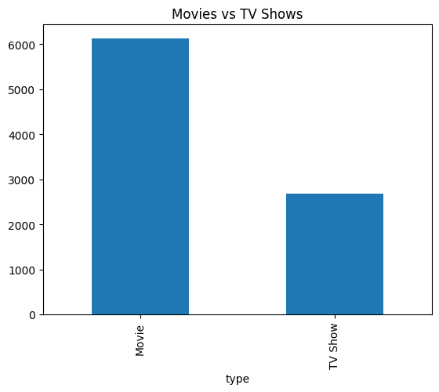

```python
#Bar Chart:
df["type"].value_counts().plot(kind="bar", title="Movies vs TV Shows")
```

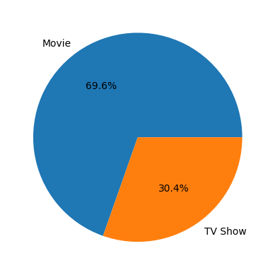

```python
#pie chart
df["type"].value_counts().plot(kind="pie", autopct="%1.1f%%")
```

### Title Acquisition by year

Netflix started acquring Titles very slowly at first then grew rapidly around 2015. This growth aligns with several initiatives by the company including Netflix World Wide, where Netflix became available in nearly every country on earth, and the beginning of Netflix Originals, where netflix became producing their own content in house. We still see that the number of movies acquired year to year, vastly outpaced TV-Shows.

```python
#count type by year:
df["year_added"] = df["date_added_parsed"].dt.year

counts_by_year = (
    df.groupby(["year_added", "type"])
      .size()
      .reset_index(name="count")
)
```

```python
#pivot data for year, Move, TV show Column
pivot_type_year = counts_by_year.pivot(
    index="year_added",
    columns="type",
    values="count"
)
```

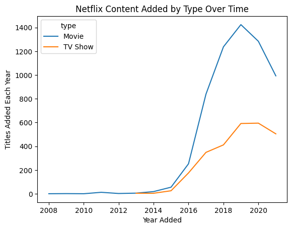

```python
ax = pivot_type_year.plot.line()
ax.set_xlabel("Year Added")
ax.set_ylabel("Titles Added Each Year")
ax.set_title("Netflix Content Added by Type Over Time")
```

##### Average Age When Acquired

Looking at the average age of the titles acquired each year will also give us insight into Netflix strategy.

```python
#let's find the average age of a movie when it was added then plot the average of each year
df["age_added"] = df["year_added"] - df["release_year"]

#average age by type
avg_age_by_type = (
    df.groupby(["year_added", "type"])["age_added"].mean()
    .reset_index(name = "avg_age")
)
```

```python
#now pivot table this
pivot_avg_age = avg_age_by_type.pivot(
    index="year_added",
    columns="type",
    values="avg_age"
)
```

##### Average Age of Title Analysis

Netflix's early offerings were much older titles that they likely were able to purchase at a cheaper rate than newer offerings. This strategy is seen in 2010 and 2011 with movies and again in 2014 with TV shows. Netflix likely went to newer Movie titles following 2011 to appeal to customers looking for recent Movies, and again we see the same behavior in 2015 for TV shows. Unlike movies however, TV show average age continue to decline after 2016 with the rise of Netflix Originals, which were heavily TV show biased. Movies begin trending older again in 2016, but this can be explained by Netflix new global market, which would drive them to add a backlog of titles developed internationally. We will investigate the dynamics of international offerings next.

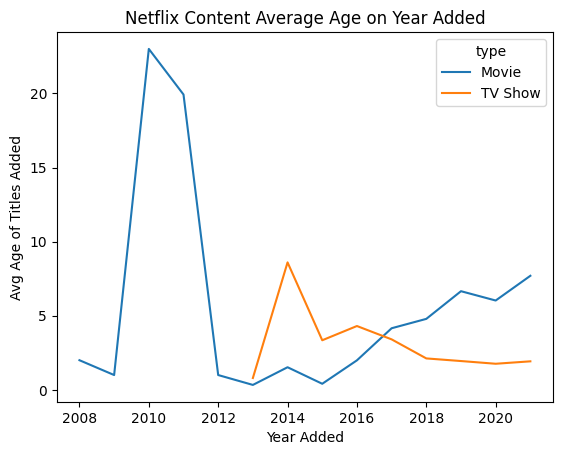

```python
ax = pivot_avg_age.plot.line()
ax.set_xlabel("Year Added")
ax.set_ylabel("Avg Age of Titles Added")
ax.set_title("Netflix Content Average Age on Year Added")
```

```python
#next let's look at average age by per year by country
avg_age_by_country = (
    df.groupby(["year_added", "country"])["age_added"].mean()
    .reset_index(name = "avg_age")
)

pivot_avg_age_country = avg_age_by_country.pivot(
    index="year_added",
    columns="country",
    values="avg_age"
)

pivot_avg_age_country
#looks like there's a lot of rows with multiple countries in the country column
```

| country year_added | , France, Algeria | , South Korea | Argentina | Argentina, Brazil, France, Poland, Germany, Denmark | Argentina, Chile | Argentina, Chile, Peru | Argentina, France | Argentina, France, United States, Germany, Qatar | Argentina, Italy | Argentina, Spain | ... | Uruguay, Argentina, Germany, Spain | Uruguay, Argentina, Spain | Uruguay, Germany | Uruguay, Guatemala | Uruguay, Spain, Mexico | Venezuela | Venezuela, Colombia | Vietnam | West Germany | Zimbabwe |
| --- | --- | --- | --- | --- | --- | --- | --- | --- | --- | --- | --- | --- | --- | --- | --- | --- | --- | --- | --- | --- | --- |
| 2008.0 | NaN | NaN | NaN | NaN | NaN | NaN | NaN | NaN | NaN | NaN | ... | NaN | NaN | NaN | NaN | NaN | NaN | NaN | NaN | NaN | NaN |
| 2009.0 | NaN | NaN | NaN | NaN | NaN | NaN | NaN | NaN | NaN | NaN | ... | NaN | NaN | NaN | NaN | NaN | NaN | NaN | NaN | NaN | NaN |
| 2010.0 | NaN | NaN | NaN | NaN | NaN | NaN | NaN | NaN | NaN | NaN | ... | NaN | NaN | NaN | NaN | NaN | NaN | NaN | NaN | NaN | NaN |
| 2011.0 | NaN | NaN | NaN | NaN | NaN | NaN | NaN | NaN | NaN | NaN | ... | NaN | NaN | NaN | NaN | NaN | NaN | NaN | NaN | NaN | NaN |
| 2012.0 | NaN | NaN | NaN | NaN | NaN | NaN | NaN | NaN | NaN | NaN | ... | NaN | NaN | NaN | NaN | NaN | NaN | NaN | NaN | NaN | NaN |
| 2013.0 | NaN | NaN | NaN | NaN | NaN | NaN | NaN | NaN | NaN | NaN | ... | NaN | NaN | NaN | NaN | NaN | NaN | NaN | NaN | NaN | NaN |
| 2014.0 | NaN | NaN | NaN | NaN | NaN | NaN | NaN | NaN | NaN | NaN | ... | NaN | NaN | NaN | NaN | NaN | NaN | NaN | NaN | NaN | NaN |
| 2015.0 | NaN | NaN | NaN | NaN | NaN | NaN | NaN | NaN | NaN | NaN | ... | NaN | NaN | NaN | NaN | NaN | NaN | NaN | NaN | NaN | NaN |
| 2016.0 | NaN | NaN | 1.000000 | NaN | NaN | 1.0 | NaN | NaN | NaN | NaN | ... | NaN | NaN | NaN | NaN | NaN | NaN | NaN | NaN | NaN | NaN |
| 2017.0 | NaN | NaN | 1.000000 | NaN | NaN | NaN | NaN | NaN | NaN | 0.5 | ... | NaN | NaN | NaN | NaN | NaN | 0.0 | NaN | 1.0 | 40.0 | NaN |
| 2018.0 | NaN | NaN | 5.250000 | 1.0 | 1.0 | NaN | 1.0 | 1.0 | 1.0 | 0.5 | ... | NaN | 0.0 | NaN | NaN | NaN | NaN | 11.0 | 3.5 | NaN | NaN |
| 2019.0 | NaN | NaN | 0.545455 | NaN | NaN | NaN | NaN | NaN | NaN | 7.0 | ... | NaN | NaN | NaN | 0.0 | 1.0 | NaN | NaN | 0.0 | NaN | NaN |
| 2020.0 | NaN | NaN | 1.500000 | NaN | NaN | NaN | NaN | NaN | NaN | 7.0 | ... | 16.0 | NaN | NaN | NaN | NaN | NaN | NaN | 0.0 | NaN | 3.0 |
| 2021.0 | 7.0 | 0.0 | 5.375000 | NaN | 15.0 | NaN | NaN | NaN | NaN | 28.0 | ... | NaN | NaN | 0.0 | NaN | NaN | NaN | NaN | 1.0 | NaN | NaN |

14 rows × 748 columns

##### Quick pause to clean country column

```python
#updating country column so if there are multiple counties they are split into separate rows
df["country"] = df["country"].str.split(", ")
df_exploded = df.explode("country")

top_countries = (
    df_exploded["country"]
    .value_counts()
    .head(10)
    .index
)

df_top = df_exploded[df_exploded["country"].isin(top_countries)]
```

```python
#trying again
#next let's look at average age by per year by country
avg_age_country = (
    df_top.groupby(["year_added", "country", "type"])["age_added"]
    .mean()
    .reset_index()
)
```

```python
#movie pivot
movies_only = avg_age_country[avg_age_country["type"] == "Movie"]

pivot_movies = movies_only.pivot(
    index="year_added",
    columns="country",
    values="age_added"
)
```

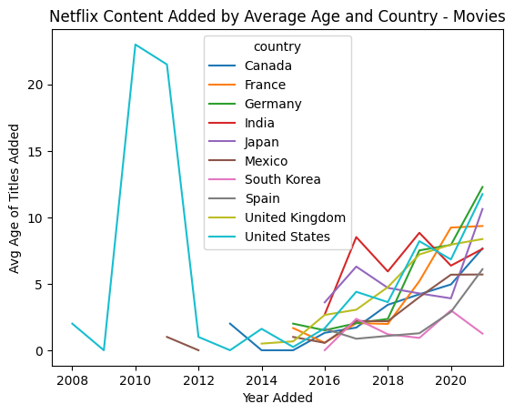

```python
ax = pivot_movies.plot.line()
ax.set_xlabel("Year Added")
ax.set_ylabel("Avg Age of Titles Added")
ax.set_title("Netflix Content Added by Average Age and Country - Movies")
```

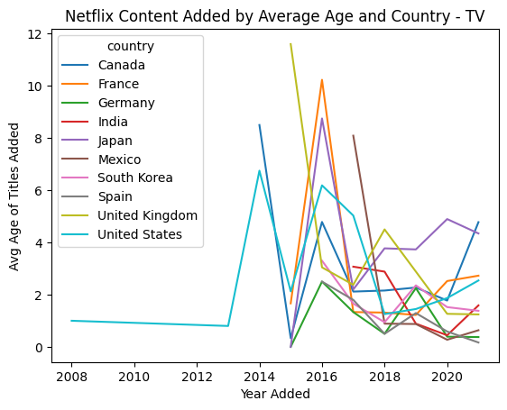

```python
#TV Show pivot
TV_Only = avg_age_country[avg_age_country["type"] == "TV Show"]

pivot_TV = TV_Only.pivot(
    index="year_added",
    columns="country",
    values="age_added"
)

ax = pivot_TV.plot.line()
ax.set_xlabel("Year Added")
ax.set_ylabel("Avg Age of Titles Added")
ax.set_title("Netflix Content Added by Average Age and Country - TV")
```

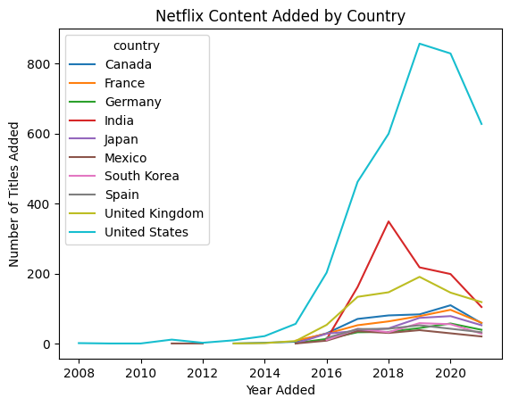

```python
#count country by year:
df["year_added"] = df["date_added_parsed"].dt.year

counts_by_country = ( df_top.groupby(["year_added", "country"]) .size() .reset_index(name="count") )

pivot_country_count = counts_by_country.pivot( index="year_added", columns="country", values="count" )

ax = pivot_country_count.plot.line()
ax.set_xlabel("Year Added")
ax.set_ylabel("Number of Titles Added")
ax.set_title("Netflix Content Added by Country")
```

### Country Data

Looking at Movies and TV shows average age at the time of being added by country, we see a similar strategy used for American audience in years prior to what was employed with Netflix Worldwide, where an initial acquisition of older titles was prioritized first, then newer titles were brought in later. This effect is much less pronounced however, suggesting a refinement in Netflix's strategy.

The far more telling info about international titles is the final graph showing the number of movies and shows by country added each year. Again we see the biggest increases in the years immediately after Netflix Worldwide in 2016, but the interesting take away is which countrie saw the largest lift; namely India and the UK. I believe India was heavily selected due to already having a large film industry and it also represents the largest population country Netflix was offered in at the time. (Netflix remains unavailable in China). Similarly an increase in UK offerings is due to an already established film industry combined with a common language with American audiences.

Again, with all of these assertions, one key piece of data missing is date removed. Adding a date removed column would give us better insight to how Netflix is shaping their offering mix. This would be a key insight to their overall strategy.

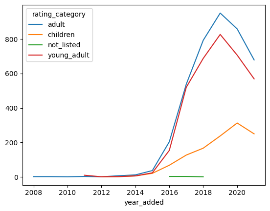

```python
#graph rating category added by year
counts_by_rating = (
    df.groupby(["year_added", "rating_category"])
      .size()
      .reset_index(name="count")
)
pivot_rating = counts_by_rating.pivot(
    index="year_added",
    columns="rating_category",
    values="count"
)

pivot_rating.plot.line()
```

### Rating Analysis

Due to the varying methods that are used to rate content, especially TV Shows, I have grouped the ratings into Children, young adult, and adult. We can see from the graph that Netflix maintained a pretty even distribution until 2015 where adult and young adult content outpaced children's content by a wide margin. Ultimately, adult content continues to be the main addition to Netflix catalogue, but adult content and young adult content started declining in 2019, while children's content continued growing until the COVID-19 pandemic. Netflix would have continued adding more children's content during this time to stay competitive with Disney+ which was launched in 2019.

# Stock

```python
#adding stock price info
df_stock = pd.read_csv("NetflixStockPrice.txt")
df_stock.head()
```

|  | year | average_stock_price | year_open | year_high | year_low | year_close | annual_percent_change |
| --- | --- | --- | --- | --- | --- | --- | --- |
| 0 | 2026 | 87.7021 | 90.990 | 99.170 | 75.860 | 92.280 | -1.58 |
| 1 | 2025 | 109.7101 | 88.673 | 133.913 | 82.840 | 93.760 | 5.19 |
| 2 | 2024 | 67.1500 | 46.850 | 93.656 | 46.850 | 89.132 | 83.07 |
| 3 | 2023 | 39.0248 | 29.495 | 49.502 | 29.276 | 48.688 | 65.11 |
| 4 | 2022 | 28.4639 | 59.737 | 59.737 | 16.637 | 29.488 | -51.05 |

```python
merged = pivot_type_year.merge(
    df_stock,
    left_index=True,
    right_on="year"
)

merged
```

|  | Movie | TV Show | year | average_stock_price | year_open | year_high | year_low | year_close | annual_percent_change |
| --- | --- | --- | --- | --- | --- | --- | --- | --- | --- |
| 18 | 1.0 | 1.0 | 2008 | 0.4095 | 0.3764 | 0.5814 | 0.2563 | 0.4270 | 12.28 |
| 17 | 2.0 | NaN | 2009 | 0.6322 | 0.4267 | 0.8733 | 0.4220 | 0.7870 | 84.31 |
| 16 | 1.0 | NaN | 2010 | 1.6824 | 0.7640 | 2.9414 | 0.7019 | 2.5100 | 218.93 |
| 15 | 13.0 | NaN | 2011 | 2.7494 | 2.5487 | 4.2676 | 0.9123 | 0.9899 | -60.56 |
| 14 | 3.0 | NaN | 2012 | 1.1855 | 1.0320 | 1.8464 | 0.7686 | 1.3227 | 33.62 |
| 13 | 6.0 | 5.0 | 2013 | 3.5272 | 1.3144 | 5.4369 | 1.3144 | 5.2596 | 297.64 |
| 12 | 19.0 | 5.0 | 2014 | 5.7495 | 5.1831 | 6.9199 | 4.4887 | 4.8801 | -7.22 |
| 11 | 56.0 | 26.0 | 2015 | 9.1896 | 4.9849 | 13.0930 | 4.5547 | 11.4380 | 134.38 |
| 10 | 253.0 | 176.0 | 2016 | 10.2030 | 10.9960 | 12.8350 | 8.2790 | 12.3800 | 8.24 |
| 9 | 839.0 | 349.0 | 2017 | 16.5374 | 12.7490 | 20.2680 | 12.7490 | 19.1960 | 55.06 |
| 8 | 1237.0 | 412.0 | 2018 | 31.9290 | 20.1070 | 41.8970 | 20.1070 | 26.7660 | 39.44 |
| 7 | 1424.0 | 592.0 | 2019 | 32.8871 | 26.7660 | 38.5030 | 25.4590 | 32.3570 | 20.89 |
| 6 | 1284.0 | 595.0 | 2020 | 44.6827 | 32.9810 | 55.6550 | 29.8840 | 54.0730 | 67.11 |
| 5 | 993.0 | 505.0 | 2021 | 55.8218 | 52.2860 | 69.1690 | 48.4980 | 60.2440 | 11.41 |

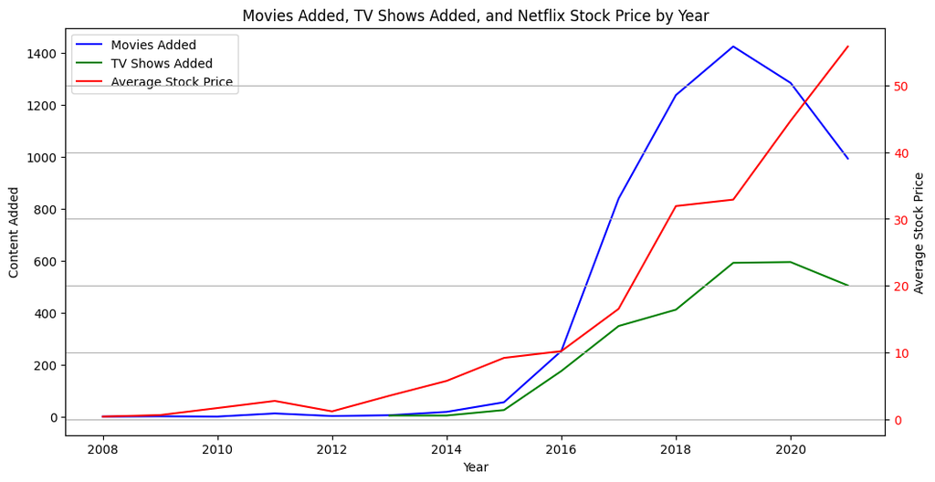

```python
fig, ax1 = plt.subplots(figsize=(12, 6))

# Left axis: content counts
ax1.plot(merged["year"], merged["Movie"], label="Movies Added", color="blue")
ax1.plot(merged["year"], merged["TV Show"], label="TV Shows Added", color="green")
ax1.set_xlabel("Year")
ax1.set_ylabel("Content Added")
ax1.tick_params(axis="y")

# Right axis: stock price
ax2 = ax1.twinx()
ax2.plot(merged["year"], merged["average_stock_price"], label="Average Stock Price", color="red")
ax2.set_ylabel("Average Stock Price")
ax2.tick_params(axis="y", labelcolor="red")

# Combined legend
lines_1, labels_1 = ax1.get_legend_handles_labels()
lines_2, labels_2 = ax2.get_legend_handles_labels()
ax1.legend(lines_1 + lines_2, labels_1 + labels_2, loc="upper left")

plt.title("Movies Added, TV Shows Added, and Netflix Stock Price by Year")
plt.grid(True)
plt.show()
```

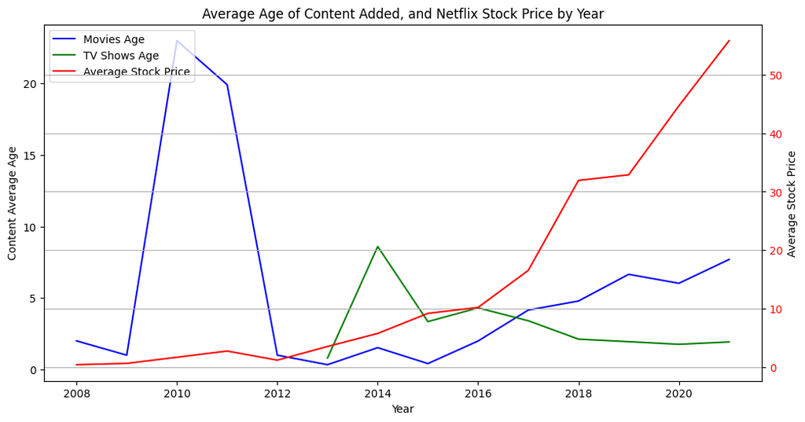

```python
merged = pivot_avg_age.merge(
    df_stock,
    left_index=True,
    right_on="year"
)

fig, ax1 = plt.subplots(figsize=(12, 6))

# Left axis: content counts
ax1.plot(merged["year"], merged["Movie"], label="Movies Age", color="blue")
ax1.plot(merged["year"], merged["TV Show"], label="TV Shows Age", color="green")
ax1.set_xlabel("Year")
ax1.set_ylabel("Content Average Age")
ax1.tick_params(axis="y")

# Right axis: stock price
ax2 = ax1.twinx()
ax2.plot(merged["year"], merged["average_stock_price"], label="Average Stock Price", color="red")
ax2.set_ylabel("Average Stock Price")
ax2.tick_params(axis="y", labelcolor="red")

# Combined legend
lines_1, labels_1 = ax1.get_legend_handles_labels()
lines_2, labels_2 = ax2.get_legend_handles_labels()
ax1.legend(lines_1 + lines_2, labels_1 + labels_2, loc="upper left")

plt.title("Average Age of Content Added, and Netflix Stock Price by Year")
plt.grid(True)
plt.show()
```